# Personal activity

boizette

28 novembre 2018

# Qualitative Human Activity Recognition

## Overview

Using devices such as Jawbone Up, Nike FuelBand and Fitbit it is now possible to collect a large amount of data about personal activity.  
The data for this project come from the source http://groupware.les.inf.puc-rio.br/har Our goal will quantify how well people do a particular activity.

## Data

We use data from accelerometers on the belt, forearm,arm and dumbell of 6 partcipants. . The training and testing data are two CSV files available inside this web site “https://d396qusza40orc.cloudfront.net/predmachlearn/

#### Data loading

```r
training<-read.csv("https://d396qusza40orc.cloudfront.net/predmachlearn/pml-training.csv",na.strings=c("","NA","#DIV/0"))
testing<-read.csv("https://d396qusza40orc.cloudfront.net/predmachlearn/pml-testing.csv",na.strings=c("","NA","#DIV/0"))
```

#### Basic summary of the data

```r
print(paste("the training dataset contain",as.character(dim(training)[1]),"rows and ",as.character(dim(training)[2]),"columns"))
print(paste("the testing dataset contain",as.character(dim(testing)[1]),"rows and ",as.character(dim(testing)[2]),"columns"))
```

```
## [1] "the training dataset contain 19622 rows and  160 columns"
## [1] "the testing dataset contain 20 rows and  160 columns"
```

The variable classe (last variable in the training set) measure how well people did the exercise.

```r
table(training$classe)
```

```
##
##    A    B    C    D    E
## 5580 3797 3422 3216 3607
```

Classe=A corresponds to the perfect execution of the exercice Other 4 classes correspond to common mistakes: Classe=B means less good etc Classe=E means very bad

#### Data Cleaning

We find that some variables contain missing values (NA).We must eliminate them because in each of those cases the pourcentage of NA is close to 100%. In addition the first 7 columns contain information unrelated to the performance. They are also eliminated

```r
l1<-apply(training,MARGIN=2,function(x) sum(is.na(x)))
l1<-l1[l1!=0]
print("% NA inside Columns which contain NA in the training dataset: ")
print(paste("% NA > ",as.character(100*min(l1)/dim(training)[1]),"%"))

m1<-apply(testing,MARGIN=2,function(x) sum(is.na(x)))
m1<-m1[m1!=0]
min(m1)
print("% NA inside Columns which contain NA in the testing dataset: ")
print(paste("% NA > ",as.character(100*min(m1)/dim(testing)[1]),"%"))
trainingbis<-training[,-which(names(training) %in% names(l1))]
trainingbis<-trainingbis[,8:dim(trainingbis)[2]]
testingbis<-testing[,-which(names(testing) %in% names(m1))]
testingbis<-testingbis[,8:dim(testingbis)[2]]
print(paste("the training dataset contain",as.character(dim(trainingbis)[1]),"rows and ",as.character(dim(trainingbis)[2]),"columns"))
print(paste("the testing dataset contain",as.character(dim(testingbis)[1]),"rows and ",as.character(dim(testingbis)[2]),"columns"))
```

```
## [1] "% NA inside Columns which contain NA in the training dataset: "
## [1] "% NA >  97.9308938946081 %"
## [1] 20
## [1] "% NA inside Columns which contain NA in the testing dataset: "
## [1] "% NA >  100 %"
## [1] "the training dataset contain 19622 rows and  53 columns"
## [1] "the testing dataset contain 20 rows and  53 columns"
```

## Sample preparation

We realize a partition of the the training data (name trainingbis) into a new training dataset (name trainingP1) and a testing dataset (name trainingP2)

```r
library(caret)
InTrain<-createDataPartition(trainingbis$classe,p=3/4)[[1]]
trainingP1<-trainingbis[InTrain,]
trainingP2<-trainingbis[-InTrain,]
```

## Model selection

The approach is as follows:

- The following models are calculated on the subsample trainingP1.
- For each model, comparaison of the precisions obtained on the subsamples trainingP1 and trainingP2 allows to check if there is to indicate that there is a situation of overfitting.
- The accuracy of each model is estimated on subsample traningP2

#### Model1 : classification trees

```r
model1<- train(classe~.,method="rpart",data=trainingP1,trControl=trainControl("cv",5),metric="Accuracy",preProcess=c("center","scale"))
pred10<-predict(model1,newdata=trainingP1)
cm10<-confusionMatrix(trainingP1$classe,pred10)
cm10
print("precision of the model1 on the subsample trainingP1:")
print(paste("overall accuracy =",cm10$overall['Accuracy']))

pred1<-predict(model1,newdata=trainingP2)
cm1<-confusionMatrix(trainingP2$classe,pred1)
cm1
print("precision of the model1 on the subsample trainingP2:")
print(paste("overall accuracy =",cm1$overall['Accuracy']))
```

```
## Confusion Matrix and Statistics
##
##           Reference
## Prediction    A    B    C    D    E
##          A 3805   63  306    0   11
##          B 1161  978  709    0    0
##          C 1198   79 1290    0    0
##          D 1091  414  907    0    0
##          E  407  355  719    0 1225
##
## Overall Statistics
##
##                Accuracy : 0.4959
##                  95% CI : (0.4877, 0.504)
##     No Information Rate : 0.5206
##     P-Value [Acc > NIR] : 1
##
##                   Kappa : 0.3411
##  Mcnemar's Test P-Value : NA
##
## Statistics by Class:
##
##                      Class: A Class: B Class: C Class: D Class: E
## Sensitivity            0.4966  0.51773  0.32816       NA  0.99110
## Specificity            0.9461  0.85424  0.88162   0.8361  0.89015
## Pos Pred Value         0.9092  0.34340  0.50253       NA  0.45270
## Neg Pred Value         0.6338  0.92325  0.78265       NA  0.99908
## Prevalence             0.5206  0.12835  0.26709   0.0000  0.08398
## Detection Rate         0.2585  0.06645  0.08765   0.0000  0.08323
## Detection Prevalence   0.2843  0.19350  0.17441   0.1639  0.18386
## Balanced Accuracy      0.7214  0.68599  0.60489       NA  0.94063
## [1] "precision of the model1 on the subsample trainingP1:"
## [1] "overall accuracy = 0.495855415137926"
## Confusion Matrix and Statistics
##
##           Reference
## Prediction    A    B    C    D    E
##          A 1270   18  104    0    3
##          B  404  308  237    0    0
##          C  388   29  438    0    0
```

[output cut: 11 more lines]

```
##  Mcnemar's Test P-Value : NA
##
## Statistics by Class:
##
##                      Class: A Class: B Class: C Class: D Class: E
## Sensitivity            0.5032  0.48125  0.32908       NA  0.99267
## Specificity            0.9475  0.84967  0.88329   0.8361  0.88988
## Pos Pred Value         0.9104  0.32455  0.51228       NA  0.45061
## Neg Pred Value         0.6426  0.91606  0.77945       NA  0.99925
## Prevalence             0.5147  0.13051  0.27141   0.0000  0.08340
## Detection Rate         0.2590  0.06281  0.08931   0.0000  0.08279
## Detection Prevalence   0.2845  0.19352  0.17435   0.1639  0.18373
## Balanced Accuracy      0.7253  0.66546  0.60618       NA  0.94127
## [1] "precision of the model1 on the subsample trainingP2:"
## [1] "overall accuracy = 0.493882544861338"
```

This mod?l is not accurate enough.

#### Model2 :Random forest

```r
model2<- train(classe~.,method="rf",data=trainingP1,trControl=trainControl(method="CV",number=5),metric="Accuracy",preProcess=c("center","scale"))
pred20<-predict(model2,newdata=trainingP1)
cm20<-confusionMatrix(trainingP1$classe,pred20)
cm20
print("precision of the model2 on the subsample trainingP1:")
print(paste("overall accuracy =",cm20$overall['Accuracy']))

pred2<-predict(model2,newdata=trainingP2)
cm2<-confusionMatrix(trainingP2$classe,pred2)
cm2
print("precision of the model2 on the subsample trainingP2:")
print(paste("overall accuracy =",cm2$overall['Accuracy']))
```

```
## Confusion Matrix and Statistics
##
##           Reference
## Prediction    A    B    C    D    E
##          A 4185    0    0    0    0
##          B    0 2848    0    0    0
##          C    0    0 2567    0    0
##          D    0    0    0 2412    0
##          E    0    0    0    0 2706
##
## Overall Statistics
##
##                Accuracy : 1
##                  95% CI : (0.9997, 1)
##     No Information Rate : 0.2843
##     P-Value [Acc > NIR] : < 2.2e-16
##
##                   Kappa : 1
##  Mcnemar's Test P-Value : NA
##
## Statistics by Class:
##
##                      Class: A Class: B Class: C Class: D Class: E
## Sensitivity            1.0000   1.0000   1.0000   1.0000   1.0000
## Specificity            1.0000   1.0000   1.0000   1.0000   1.0000
## Pos Pred Value         1.0000   1.0000   1.0000   1.0000   1.0000
## Neg Pred Value         1.0000   1.0000   1.0000   1.0000   1.0000
## Prevalence             0.2843   0.1935   0.1744   0.1639   0.1839
## Detection Rate         0.2843   0.1935   0.1744   0.1639   0.1839
## Detection Prevalence   0.2843   0.1935   0.1744   0.1639   0.1839
## Balanced Accuracy      1.0000   1.0000   1.0000   1.0000   1.0000
## [1] "precision of the model2 on the subsample trainingP1:"
## [1] "overall accuracy = 1"
## Confusion Matrix and Statistics
##
##           Reference
## Prediction    A    B    C    D    E
##          A 1393    2    0    0    0
##          B    5  943    1    0    0
##          C    0    1  853    1    0
```

[output cut: 11 more lines]

```
##  Mcnemar's Test P-Value : NA
##
## Statistics by Class:
##
##                      Class: A Class: B Class: C Class: D Class: E
## Sensitivity            0.9964   0.9958   0.9861   0.9962   0.9989
## Specificity            0.9994   0.9985   0.9995   0.9973   0.9990
## Pos Pred Value         0.9986   0.9937   0.9977   0.9863   0.9956
## Neg Pred Value         0.9986   0.9990   0.9970   0.9993   0.9998
## Prevalence             0.2851   0.1931   0.1764   0.1623   0.1831
## Detection Rate         0.2841   0.1923   0.1739   0.1617   0.1829
## Detection Prevalence   0.2845   0.1935   0.1743   0.1639   0.1837
## Balanced Accuracy      0.9979   0.9971   0.9928   0.9968   0.9989
## [1] "precision of the model2 on the subsample trainingP2:"
## [1] "overall accuracy = 0.994902120717781"
```

This second mod?l is very precis (Accuracy very high). In addition the comparaison of the precisions obtained on the subsamples trainingP1 and trainingP2 seems to indicate that there is no overfitting.

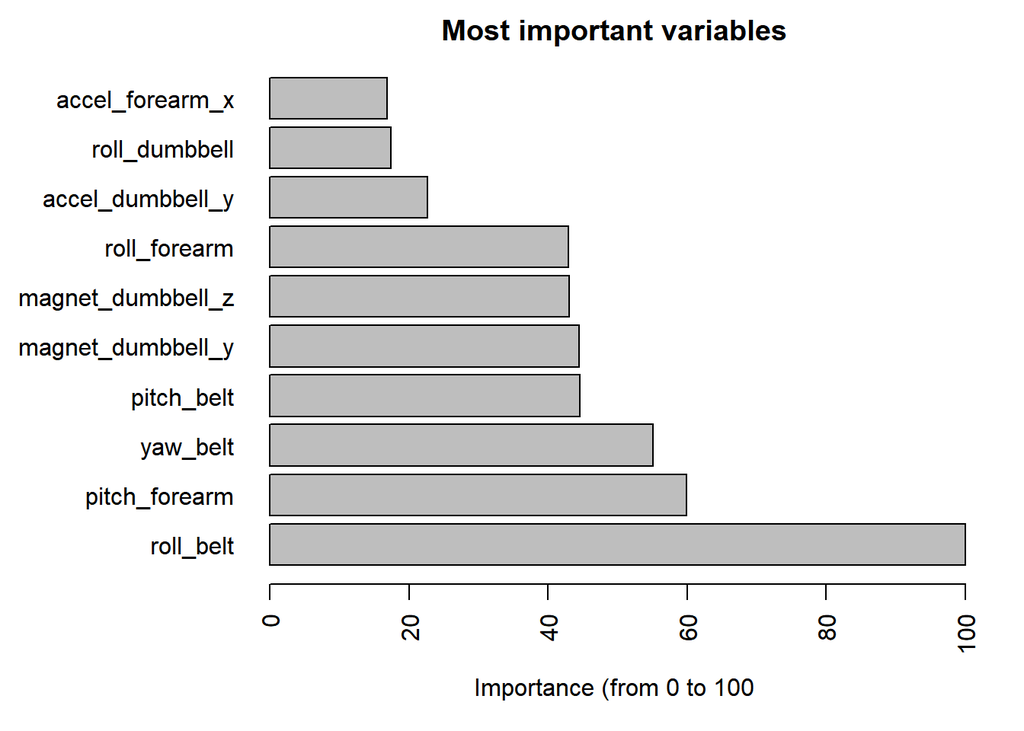

```r
g1<-varImp(model2,scale=TRUE)$importance$Overall
g2<-names(trainingbis)[1:52]
gg<-data.frame(variable=g2,importance=g1)
ggp<-gg[order(-gg$importance,gg$variable),][1:10,]
par(mar=c(5,9,2,2))
barplot(ggp$importance,names.arg=ggp$variable,horiz=TRUE,las=2,xlab="Importance (from 0 to 100",main="Most important variables")
```

## Prediction on test dataset (named testingbis)

Applying the model2 (based on the random forest), we are able to predict the 20 values of variable “classe” on the sample of 20 observations (named testingbis)

```r
predfinal<-predict(model2,newdata=testingbis)
predfinal
```

```
##  [1] B A B A A E D B A A B C B A E E A B B B
## Levels: A B C D E
```